# Download ChatGPT conversations

Demo in: https://sonsoleslp.shinyapps.io/chatgptscraper/

Based on https://github.com/sonsoleslp/chatgptscrapeR/

With the rise of conversational AI tools like ChatGPT, educators now have access to powerful resources that can enrich the learning experience. However, effectively utilizing these tools requires efficient methods for collecting and analyzing interaction data. Traditional approaches—such as relying on APIs or manually retrieving data—can be cumbersome and inefficient. To address these challenges, we are excited to introduce the *chatGPTscraper* app —a tool designed to streamline the integration of ChatGPT interactions into learning analytics interventions.

The app allows teachers to download students’ interactions with ChatGPT by entering the URLs of the conversations provided by the students. This way teachers can easily analyze the content of the conversations both for research and educational purposes. Here’s a brief guide to getting started:

- **Access the App**: Visit https://sonsoleslp.shinyapps.io/chatgptscraper
- **Upload Data**: Input a csv/Excel file containing the URLs of the conversations.

[figure not shown]

- **Analyze Interactions**: Use the app’s interactive tools to view and analyze conversation logs and statistics. You can also download the conversations to analyze them offline-

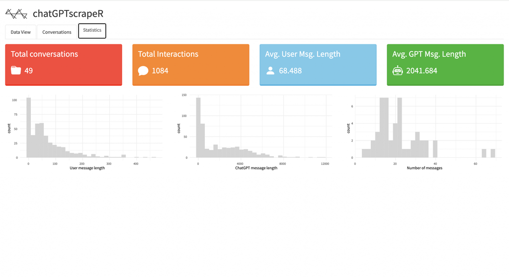

The *chatGPTscraper* app represents a significant advancement in integrating AI tools into leanring analytics. It offers a user-friendly interface that empowers educators to make informed decisions and enhance their teaching practices. This innovative tool aligns perfectly with the ISILA[^1] project’s mission to improve student engagement and success, making it a valuable addition to any educational toolkit. We encourage educators to explore the app and see how it can support your efforts in creating a more responsive and effective learning environment. The app is based on the R library of the same name (chatgptscraper), also developed within the scope of ISILA, which can be used seamlessly in R scripts to retrieve conversation data.

[^1]: ISILA: https://blogs.uef.fi/isila